# Agonal factors during the dying process

By: Andrew McKenzie; Last Major Update: 2022-04-03; Status: Draft

- Link to the index: https://brainpreservation.github.io/

## Summary

The agonal phase is the period of time prior to one’s death during which the brain and the rest of the body are under grave physiologic stress. Its length can vary from minutes to hours to days to weeks. Brain deterioration during the agonal period is often considered more damaging than the postmortem interval in the brain banking literature, depending of course on the relative length of each. It has been historically underrated in the cryonics/brain preservation discussion, although this has been changing in recent years.

Agonal factors can lead to alterations in blood flow, invasion of immune cells, invasion of microorganisms, damage to brain cells, or loss of viability of brain cells. Examples of severe agonal conditions include prolonged unresponsive wakefulness syndrome or brain death. In extremely severe agonal circumstances, information-theoretic death could theoretically occur prior to the declaration of legal death. For example, in many jurisdictions, the legal declaration of brain death may be delayed, and during this delay the brain will be decomposing to a significant degree. Options employed by people interested in brain preservation to control the timing of their own legal death also involve agonal factors.

Overall, the effects of agonal state on brain tissue quality are highly variable and poorly mapped out. Understanding how agonal factors lead to damage and how to prevent it is critical to achieve consistently high preservation quality in realistic cases.

## Neurobiological disorders during life

Maintaining a healthy brain is a lifelong challenge. It not only requires a multifactorial approach to brain health, but also an enormous amount of good luck. Numerous neurobiological disorders and injuries can alter the information in the brain encoding one’s memories and personality. I note this here just to make the obvious point that damage to structures in the brain, including engrams, can begin far prior to one’s legal death. [(von Verschuer, 2020)](https://www.tandfonline.com/doi/full/10.1080/1600910X.2019.1610016) points out that life and death may be better thought of as a living-dying process.

It is possible for many neurobiological disorders, such as Alzheimer’s disease and cerebrovascular disease, to alter the *accessibility* of neural information beyond the degree to which they alter the underlying information. For example, these disorders can cause disconnection syndromes [(Catani et al., 2005)](https://pubmed.ncbi.nlm.nih.gov/16141282/), wherein most or all of the encoded information is likely still present in the grey matter of the cerebral cortex but cannot be correctly communicated across white matter regions. The potential for information persistence in dementia is suggested by moments of lucidity [(Mashour et al., 2019)](https://pubmed.ncbi.nlm.nih.gov/31229433/). Because of the reasonable possibility that information could potentially be recovered in the future during the process of inference and repair, as well as basic humanity, there is a good argument that access to brain preservation should not be restricted based on therapeutic nihilism regarding illness.

## Definitions of agonal damage

Brain deterioration often accelerates dramatically in the weeks, days, and hours prior to the legal declaration of death. Some definitions are helpful to frame the discussion about the agonal state.

In the brain banking literature, the agonal phase refers generally to the medical condition of the person in the days and hours leading up to their death [(White et al., 2018)](https://www.liebertpub.com/doi/full/10.1089/bio.2017.0099). To operationalize agonal factors, one study simply distinguishes between two categories of brain donors: one group that died after a period of normal or near-normal health and one that died after a long period of severe illness [(Perry et al., 1982)](https://www.sciencedirect.com/science/article/abs/pii/0304394082903342). In this essay, I use the term agonal phase as it is used in the brain banking literature.

One source from the cryonics literature describes the agonal phase in a holistic way as the period of time during which a person transitions from a terminal illness to physiologic exhaustion [(de Wolf et al., 2019)](https://www.alcor.org/Library/pdfs/Cryopreservation-Procedures-Section-01-Introduction.pdf). These symptoms include changes in breathing such as apnea, loss of the ability to swallow, a drop in blood pressure, peripheral ischemia, and increasing confusion. This is effectively the same definition as that in the brain banking literature.

In the organ donation literature, the agonal phase is defined as the period of time between when life support is withdrawn and cardiorespiratory arrest occurs [(Akoh, 2012)](https://www.ncbi.nlm.nih.gov/pmc/articles/PMC3782200/). Damage during this time period is highly germane to the quality of donated organs, so much so that some centers have abandoned organ donation if the agonal phase lasts more than one hour [(Akoh, 2012)](https://www.ncbi.nlm.nih.gov/pmc/articles/PMC3782200/). This is a different definition of the agonal phase.

There are two major ways to study agonal factors: one is to try to group all causes of legal death into a global agonal severity grading system and the other is to consider causes of legal death separately by their particular agonal effects.

## Global agonal damage scoring schemes

In the brain banking literature, there have been various schemes that have attempted to classify the severity of agonal damage into a unified severity measure.

[(Hardy et al., 1985)](https://pubmed.ncbi.nlm.nih.gov/3989524/) proposed this classification of increasing severity of agonal damage based on the type of death:

> 1. Violent fast death. The causes of death of these cases were shooting (accidental, homocidal or suicidal) or blunt trauma.
> 2. Fast death of natural causes. This category was defined as sudden, unexpected death of people who had apparently been reasonably healthy. The most frequent cause of death in this group was a myocardial infarction. Most of these cases died at home.
> 3. Intermediate death. This group consisted of patients who were ill but whose deaths were unexpected. They could neither be classified as sudden deaths (above) nor as slow deaths (below). Most of these cases died in hospital.
> 4. Slow death. This was defined as a death after a long illness with a prolonged terminal phase. Typically these patients died from cancers, cerebrovascular disease or bronchopneumonia. Most of these cases died in hospital.

[(Hardy et al., 1985)](https://pubmed.ncbi.nlm.nih.gov/3989524/) found that pH correlated with the cause of death down the severity scale:

- Violent fast death = least acidotic (average pH around 7.1)
- Fast death of natural causes = intermediate acidotic (average pH around 6.8)
- Intermediate and slow death = most acidotic brain tissue (average pH around 6.4)

As background, when cells have a relative deficiency of blood flow and/or oxygen, to produce energy (ATP) they increase the rate with which they convert glucose → pyruvate → lactate to produce energy. This is called anaerobic glycolysis [(Melkonian et al., 2022)](https://www.ncbi.nlm.nih.gov/books/NBK546695/).

Anaerobic metabolism is necessary in the short run to keep cells functioning, but in the longer run the build up of lactate causes problems for cells and tissues. It leads to the accumulation of hydrogen atoms, which means that the pH is lowered [(Foucher et al., 2022)](https://www.ncbi.nlm.nih.gov/books/NBK470202/).

The accumulation of lactate and the lowering of the pH is thought to contribute to neurotoxicity [(Hardy et al., 1985)](https://pubmed.ncbi.nlm.nih.gov/3989524/). Classic experiments suggest that lowering pH tends to increase the speed of autolysis by activating autolytic enzymes and accelerating the decomposition of tissues [(Kies et al., 1942)](https://www.jbc.org/content/145/2/685.short). This neurotoxicity might contribute to legal death and it also might cause deterioration of the biomolecule-annotated connectome.

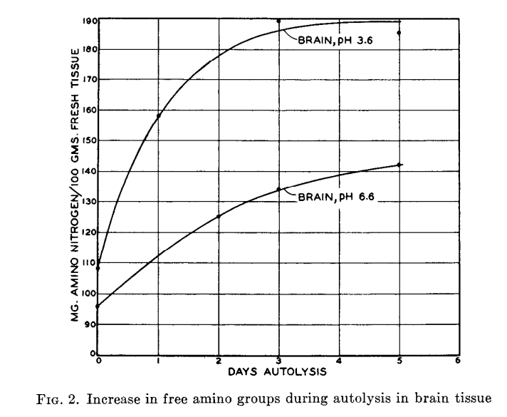

Activation of autolytic enzymes via lower pH is thought to accelerate the breakdown of proteins, leading to more free amino groups; [(Kies et al., 1942)](https://www.jbc.org/content/145/2/685.short)

Low pH is often used as a proxy for prolonged agonal states [(Tashjian et al., 2019)](https://www.ncbi.nlm.nih.gov/pmc/articles/PMC6777723/). Brain tissue with low pH, for example with a pH of less than 6.0, is sometimes excluded from brain banking studies [(McCullumsmith et al., 2014)](https://www.nature.com/articles/npp2013239).

On the other hand, studies have found that the correlation between postmortem interval and pH is not very strong, potentially because much of the lactate accumulation occurs prior to and just after clinical death [(Tashjian et al., 2019)](https://www.ncbi.nlm.nih.gov/pmc/articles/PMC6777723/).

It’s worth noting that the effects of agonal stress are broad and that attempting to account for them with pH alone may not capture the full picture, especially via just a pH measurement in one brain region [(Li et al., 2007)](https://bmcgenomics.biomedcentral.com/articles/10.1186/1471-2164-8-336).

[(Johnston et al., 1997)](https://pubmed.ncbi.nlm.nih.gov/9402561/) used the following criteria for increasing severity of the agonal state, or as they also describe it, the rapidity of death:

> A [rapidity of death] measure was assigned using the following criteria:
> 1. Almost instantaneous death, e.g. gunshot wound to the heart, drowning, vehicle accident with death at the scene.
> 2. Death within 24 h of exciting cause and with minimal evidence of cerebral hypoxia, e.g. vehicle accident with death from internal bleeding occurring several hours later, sedative overdose.
> 3. Death within 24 h of exciting cause, but with presumption of some cerebral hypoxia, e.g. carbon monoxide poisoning.
> 4. Slow death occurring over period of 24 h, e.g. death from carcinoma.
> 5. Slow death with assisted ventilation.

They found that groups 3-5 had lower brain pH levels than groups 1 and 2. They also found that the pH was consistent across brain regions.

[(Sherwood et al., 2011)](https://pubmed.ncbi.nlm.nih.gov/21251045/) proposed an agonal factor score that attempted to aggregate different factors:

| Factors | Score |
| --- | --- |
| Duration | +1 for each 9 months of illness |
| Seizures | 0 for absent, 1 for present |
| Pyrexia | 0 for absent, 1 for present |
| Coma | 0 for absent, 1 for present |
| Hypoglycemia | 0 for none, 1 for evidence of, 2 for severe |
| Neurotoxic substances | 0 for absent, 1 for present |
| Dehydration | 0 for none, 1 for evidence of, 2 for severe |
| Mode of death | 0 to 4 [based on (Hardy et al 1985)] |
| Multiple organ failure or head injury | 0 for absent, 1 for present |
| Hypoxic and/or ischemic change | 0 for none, 1 for evidence of, 2 for severe |

One study found that brains donated from the medical examiner had a higher pH and better RNA quality [(Stan et al., 2006)](https://www.ncbi.nlm.nih.gov/pmc/articles/PMC1995236/). This is consistent with a fast and unexpected death having a correlation with lower agonal stress. However, this was after selecting out medical examiner cases that did not meet the criteria of their brain collection, such as drug abuse, infectious diseases, and head injury, which introduced a selection bias that is difficult to adjust for. Selection biases, by the way, are omnipresent in the brain banking literature.

### Effects of agonal factors on RNA

One of the major uses of postmortem brain tissue over the last couple of decades has been analyzing its RNA content. RNA is easy to measure, relatively stable in postmortem tissue, and a useful window into the state of the brain tissue.

Once people developed methods to analyze all of the types of RNA in the brain at once (called transcriptomics), it was discovered that agonal factors seemed to be the most important factor in mediating variation in RNA content. As [(Li et al., 2007)](https://bmcgenomics.biomedcentral.com/articles/10.1186/1471-2164-8-336) put it:

> [T]issue pH and near-death physiological stress can exert a major influence on the inter-individual variation of expression patterns. The impact of pH/agonal stress is so strong that it often far outweighs the influence of all other factors, including age and gender, and can obviate the detection of the impact of the illness.

For example, [(Li et al., 2004)](https://academic.oup.com/hmg/article/13/6/609/605073) found that agonal factors, as proxied by the pH of the brain tissue, was the strongest source of variation in determining the RNA content of the brains they studied. More so than age, postmortem interval, or clinical diagnosis. They found that the main distinction was between:

1. Donors whose brains “shut down” suddenly in minutes, prior to exhausting ATP store in cells, so that cells did not have time to increase the levels of stress response transcripts.

2. Donors whose brains experienced hours of metabolism in stress conditions, during which the levels of transcripts related to aerobic metabolism decreased significantly.

Several studies since have also used transcriptomics to build on these results.

[(Hagenauer et al., 2018)](https://journals.plos.org/plosone/article?id=10.1371/journal.pone.0200003) found that prolonged hypoxia, as measured by low pH or high agonal score, was associated with significant increases in endothelial cell and astrocyte gene expression, alongside significant decreases in neuronal gene expression markers. This suggests that cells are at a minimum actively altering their gene expression, and may be dying/proliferating, to compensate for a prolonged hypoxic environment.

[(Dai et al., 2021)](https://www.frontiersin.org/articles/10.3389/fnins.2021.614142/full) found that agonal fever was associated with a significantly higher proportion of immune cells in the brain.

Some studies have also noted that brain tissue pH is a useful proxy for protein integrity, such as the review by [Tashjian et al 2019](https://www.ncbi.nlm.nih.gov/pmc/articles/PMC6777723/).

This result, while interesting, shouldn’t necessarily be taken to mean that the agonal state is more important than the postmortem interval, or other factors, in terms of loss of information contained in the biomolecule-annotated connectome. RNA is a relatively transient marker of tissue state, and it is actively produced during the agonal state (vs much less so in the postmortem interval), so it makes sense that RNA content, especially metabolic transcripts, would be highly affected by agonal factors.

### Histologic effects of agonal factors, including hypoxia

From the perspective of the biomolecule-annotated connectome, transcriptomics does not seem to matter as much as cell morphology, which is generally measured by [histology](https://en.wikipedia.org/wiki/Histology). It is theoretically possible to lose RNA content without losing the actual biomolecules that mediate rapid electrochemical information flow through the connectome. Of greater concern, it is also possible to maintain adequate global biomolecular content even though morphology may be dramatically altered, for example if key RNA or protein molecules have diffused away from their original locations.

There seems to be less data regarding agonal effects on histology than on gene expression, perhaps because it is harder to study. I did a search for articles on this topic, which can be found [here](https://sysrev.com/u/5668/p/89398%5D) [*search query*: (histology OR microscopy) AND (agonal OR perimortem) AND (brain OR “Brain”[Mesh])]. Reviewing these studies may help us to predict the effect of agonal factors on the biomolecule-annotated connectome. In no particular order, here are some of the results I found through this search and related searches:

1. [(Williams et al., 1978)](https://pubmed.ncbi.nlm.nih.gov/73572/) described the use of Golgi staining in postmortem human brains. Golgi staining can measure cellular morphology. They reported the quality of the result as excellent, satisfactory, or poor.

They were studying the effect of postmortem delay on Golgi staining quality. They found that this relationship was less predictable than in experimental animals.

They attributed this to the duration of premortem metabolic encephalopathy, which only occured in the donated human brains. Specifically, they reported that if the degree of terminal unresponsiveness, the postmortem delay, or both in combination was greater than 6 hours, then they rarely found Golgi staining of excellent quality.

One of the difficulties in evaluating the results of this study is that the staining method they used is capricious. Their results are susceptible to “label degradation bias” associated with prolonged agonal conditions, wherein their Golgi staining might have failed for other reasons, such as problems with filling of the cell membranes, rather than true decomposition of the dendrites. However, their results are certainly an important data point of how agonal conditions can affect the cell membrane connectome.

2. [(Poloni et al., 2021)](https://onlinelibrary.wiley.com/doi/10.1111/bpa.12997) studied the histopathologic effects on the brain of Covid-19 infection. They found that the infection caused edema, inflammatory infiltrates, and small vessel disease in the white matter. They described all of these findings as non-specific hypoxic and agonal changes.

3. [(Harrison et al., 1995)](https://pubmed.ncbi.nlm.nih.gov/9064599) described the effects of the agonal state on CA1, which is a subregion of the hippocampus. They stated that brain pH was associated with increased agonal severity, but that pH was independent of the presence or absence of hypoxic histologic changes in CA1. It’s unclear how hypoxic histologic changes in CA1 were actually measured in their study.

4. [(Barranco et al., 2021)](https://www.ncbi.nlm.nih.gov/pmc/articles/PMC8238305) did a systematic review on the neuropathologic diagnosis of acute cerebral hypoxia. They found that staining for the protein microtubule-associated protein 2 (MAP2) was the most specific finding for cerebral hypoxia. They describe how MAP2 levels have been found to decrease after only minutes following causes of death associated with cerebral hypoxia, such as hanging and drowning. MAP2 is a cytoskeleton protein enriched in dendrites and staining it is widely used to measure dendrite morphology. Because levels of MAP2 staining can decrease in only minutes of hypoxia, which is shorter than has been found to be recoverable, the loss of MAP2 staining itself seems to be due to label degradation, and not indicative of loss of dendrite morphology information altogether.

5. [(Uchikado et al., 2004)](https://pubmed.ncbi.nlm.nih.gov/14762673/) studied inflammatory markers of blood vessels via histology and found that they were activated in the brains of those who had systemic inflammation prior to death. They suggested that this might help to explain the neuropsychiatric condition of delirium.

6. [(Paasila et al., 2019)](https://pubmed.ncbi.nlm.nih.gov/30803086/) found that dystrophic microglia were associated with low brain pH and prolonged agonal states. This is consistent with the idea that neuroimmune activation is a key component of agonal damage.

7. [(Ohm et al., 1994)](https://pubmed.ncbi.nlm.nih.gov/7534362/) studied the effects of the postmortem interval and the agonal state on neuronal geometry in human brains using an intracellular filling dye. They found that sudden death seemed to have a correlation with better neuronal staining, although the statistical evidence they presented was not very strong.

> When the brain has been properly dissected after adequate fixation (up to three weeks’ immersion in buffered 10 per cent formol saline) an infarct of about 18 to 24 hours’ duration may just be recognizable but even an experienced neuropathologist may fail to identify extensive diffuse hypoxic brain damage if it is less than some three to four days’ duration… The time course of ischaemic cell change is relatively constant for neurons according to their size and site so that the interval between a hypoxic episode and death if between two and 18 to 24 hours can be assessed with reasonable accuracy. If the patient survives for more than 24 to 36 hours more advanced changes occur in neurons, and early reactive changes appear in astrocytes, microglia and endothelial cells. After a few days the dead nerve cells disappear and reactive changes become more intense, including the formation of lipid phagocytes, even though the latter may not appear if damage is restricted to neuronal necrosis. When survival is for more than a week or so the damaged tissue becomes rarefied due to loss of myelin and there is a reactive gliosis. Collagen and reticulin fibers are also laid down, the whole appearing as a glio-mesodermal reaction.

### Brain bank exclusions based on agonal state

As a general rule, what human brain bank studies have found is that prolonged agonal states cause a lot of damage to brain tissue [(McCullumsmith et al., 2014)](https://www.nature.com/articles/npp2013239). Brain banks often do not accept brains from donors with prolonged agonal states, because the amount of damage is so severe that it is thought to be too difficult to learn useful information from this type of brain tissue. As [(McCullumsmith et al., 2014)](https://www.nature.com/articles/npp2013239) put it, “[w]hile manner of death impacts measures of gene expression, most brain collections do not include subjects with prolonged agonal status, making this issue more of a theoretical concern.” For example, one brain bank reported that they exclude brain donors in which the person had a respiratory infection or had artificial ventilation prior to death [(White et al., 2018)](https://www.ncbi.nlm.nih.gov/pmc/articles/PMC5906728/).

## Agonal damage based on specific causes of legal death

Specific etiological factors of clinical death can lead to many different types and degrees of agonal damage. One of the main sources of information on this topic is from neuropathology studies that have compared brain tissue quality between these types of death. It’s hard to reach conclusive statements in part because these studies tend to be small and do not focus on the biomolecule-annotated connectome as an outcome metric.

### Sepsis

Sepsis involves the body’s response to systemic inflammation, in some cases a circulatory infection such as bacteremia. If it does not improve, it eventually leads to multi-organ failure. Sepsis causes inflammatory changes in the brain that also lead to deficits in blood flow to the brain [(Burkhart et al., 2010)](https://www.ncbi.nlm.nih.gov/pmc/articles/PMC2887108/). Sepsis is quite a confusing topic and one of the main things I learned about it in medical school is that it has many different definitions that tend to change all the time.

[(Garofalo et al., 2019)](https://www.ncbi.nlm.nih.gov/pmc/articles/PMC6658642/) reviewed the histologic alterations seen in sepsis. Neuronal apoptosis, a form of programmed cell death, was one of the common neuropathologic correlates of sepsis. Other findings were primarily related to alterations in microcirculation, such as disseminated microabscesses, pericapillary hemorrhages, or ischemic alterations in susceptible regions.

Overall, it is clear that death associated with sepsis causes brain decomposition. Unless it is highly prolonged and/or severe, sepsis-induced encephalopathy seems to me to be unlikely to cause information-theoretic death on its own. In part, this is based on reviewing the neuropathology evidence described above, and in part this is because sepsis is a condition from which people can recover with cognitive largely intact if the physiologic stressors can be reversed.

However, I don’t know of any good data showing that neuropathologic changes resulting from sepsis would not irretrievably damage the biomolecule-annotated connectome. So this is primarily based on a feeling and a global impression. Sepsis is extremely common, being present at the time of death in 53% of the cases in acute care US hospitals according to one study [(Rhee et al., 2019)](https://jamanetwork.com/journals/jamanetworkopen/fullarticle/2724768). Given how common it is at the time of death in realistic cases, the unknown extent of damage to the biomolecule-annotated connectome in sepsis is one example of why there is so much uncertainty in brain preservation.

### Localized lesions of the brain

Another type of death to consider is death associated with direct damage to at least one area of the brain. Examples include brain trauma, ischemic stroke, hemorrhagic stroke, or brain abscess. The degree of damage that these lesions could cause is significant.

That said, it’s important to not have therapeutic nihilism about localized brain lesions related to the cause of death. As [previously discussed](https://brainpreservation.github.io/Embodied_Brain#robustness-of-brain-information), people have lost whole hemispheres in a hemispherectomy and have still been found to retain memories and personality. Moreover, much of the damage in localized lesions to the brain, such as what occurs following a focal ischemic stroke, is a delayed, active response to an interruption in blood flow that takes hours to days of metabolic activity in the brain to evolve [(Lipton, 1999)](https://journals.physiology.org/doi/full/10.1152/physrev.1999.79.4.1431). If a localized brain lesion is shortly followed by clinical death, then active metabolism will soon stop, and such active remodeling in response to injury will not occur.

The more concerning aspect of localized brain lesions might be the secondary reactions that can potentially occur more diffusely throughout the brain. This might include cerebral edema, which could cause osmotic or compression-based damage to cells throughout the brain or more widespread interruptions in blood flow due to systemic inflammation.

### Unresponsive wakefulness syndrome

Unresponsive wakefulness syndrome was previously known as persistent vegetative state [(Laureys et al., 2010)](https://www.ncbi.nlm.nih.gov/pmc/articles/PMC2987895/). In this condition, people’s brains maintain key physiologic functions necessary for living, including autonomic control, sleep-wake cycles, and ventilation, but lose cognitive and emotional functions [(Kinney et al., 1994)](https://pubmed.ncbi.nlm.nih.gov/7964896/). It is most commonly due to bilateral damage to the cerebral cortex, subcortical white matter, and/or the thalamus.

Unresponsive wakefulness syndrome often occurs after a course of severe illness with artificial ventilation to provide respiration. Damage to the cerebral cortex and/or thalamus in this condition is not always present or widespread [(Kinney et al., 1994)](https://pubmed.ncbi.nlm.nih.gov/7964896/). And unresponsive wakefulness syndrome is certainly not always permanent – people diagnosed with this condition have absolutely regained function later [(Laureys et al., 2010)](https://www.ncbi.nlm.nih.gov/pmc/articles/PMC2987895/).

However, while there are some cases where the brain tissue has surprisingly little damage, prolonged survival with unresponsive wakefulness syndrome *can* be associated with severe damage to the brain [(Kinney et al., 1994)](https://pubmed.ncbi.nlm.nih.gov/7964896/) [(Graham, 1977)](https://jcp.bmj.com/content/jclinpath/s3-11/1/170.full.pdf). If so, the condition of unresponsive wakefulness syndrome could potentially lead to information-theoretic death prior to the declaration of legal death. Fortunately, unresponsive wakefulness syndrome has a low prevalence of approximately 1 per 100,000 people [(van Erp et al., 2020)](https://www.ncbi.nlm.nih.gov/pmc/articles/PMC6972677/).

### Brain death

Brain death generally occurs due to a lack of blood flow to areas of the brain. The person is only able to oxygenate the rest of their tissues because of artificial ventilation.

From the perspective of brain information conservation, brain death is one of the most damaging causes of legal death. There is already decomposition of brain tissue in the same way that there would be following circulatory death. If anything, the decomposition of brain tissue is amplified because the temperature of the cortical surface may be slightly higher than it would be if the person’s heart were no longer beating, for example if there is still residual blood flow through the external carotid artery [(Wang et al., 2014)](https://www.frontiersin.org/articles/10.3389/fnins.2014.00307/full) [(Schöning et al., 2005)](https://pubmed.ncbi.nlm.nih.gov/16082327/). The relative warmth of the brain could mitigate the autolytic enzyme inactivation that often occurs after legal death as a result of the slight drop in temperature.

Studies have found that brain death is associated with a massive amount of decomposition histologically, and that the longer the duration of brain death, the higher the degree of autolysis (as cited in [(Sheleg et al., 2010)](https://www.ncbi.nlm.nih.gov/pmc/articles/PMC2480568/)) [(Ujihira et al., 1993)](https://europepmc.org/article/med/8319384).

Even with a short postmortem interval following the declaration of legal death, a long enough interval of time spent on artificial life support with brain death does a tremendous amount of damage to the brain. As one example of many, in a study on perfusion fixation of the inner ear, [(Kong et al., 1994)](https://www.ncbi.nlm.nih.gov/pubmed/7915484) reported a representative finding when they performed perilymphatic perfusion fixation of the cochlea in different groups of donors. They found that fixation quality was particularly poor in patients who had died of brain death and were in that state for at least 7.5 hours, even if the postmortem interval was quite low (2.5 hours or less) prior to preservation. This was most likely due to tissue degradation because of limited to no blood flow to the cochlea in the setting of brain death.

In the history of cryonics, several people who were eventually cryopreserved had been maintained with artificial ventilation and signs of lack of cerebral blood flow for weeks. de Wolf and Platt describe such a case of a person who was cryopreserved at Alcor [(de Wolf et al., 2019)](https://www.alcor.org/Library/pdfs/Cryopreservation-Procedures.pdf). It seems there is sometimes a lack of understanding that brain death is highly damaging to brain tissue and could clearly cause information-theoretic death.

From the perspective of brain preservation, it is encouraging that the majority of deaths are due to circulatory death rather than brain death. According to one source, brain death is currently 2% of deaths in the United States, usually as a result of stroke, TBI, or cardiac arrest followed by recovery with anoxic injury to the brain [(Seifi et al., 2020)](https://www.sciencedirect.com/science/article/pii/S0303846720302286). In brain death, current recommendations are to wait at least 24 hours from the initial diagnosis to establish certainty [(Seifi et al., 2020)](https://www.sciencedirect.com/science/article/pii/S0303846720302286).

## Controlling the timing of one’s legal death

The two main options that people can use to control the timing of their legal death are voluntary stopping of eating and drinking (VSED) and medical aid in dying (MAID). Unfortunately, medical aid in dying is highly restricted in the United States, both to certain legal jurisdictions and to certain diagnoses. It is important to understand that these causes of legal death could also be associated with agonal damage to the brain.

### Voluntary stopping of eating and drinking

Voluntary stopping of eating and drinking (VSED) is used by people who want to legally die. Intuitively, VSED could be associated with significant suffering, but sometimes people have no other recourse. However, some reports suggest that the quality of life for people dying in this way can be good [(Ganzini et al., 2003)](https://www.nejm.org/doi/full/10.1056/nejmsa035086).

VSED does not cause immediate death. de Wolf and Platt report that categorical denial of food and drink generally leads to legal death by circulatory arrest in 7-15 days [(de Wolf et al., 2019)](https://www.alcor.org/library/human-cryopreservation-procedures/). A less categorical approach is not as predictable and has been reported to lead to legal death in more than a month.

One survey of nurses found that in VSED, it takes on average 10 days for someone to legally die and that 85% of people died within 15 days [(Ganzini et al., 2003)](https://www.nejm.org/doi/full/10.1056/nejmsa035086). For example, in one case report, death by stopping drinking took 9 days [(Malpas, 2017)](https://www.ncbi.nlm.nih.gov/pmc/articles/PMC5378484).

What is the cause of death in VSED? In the absence of fluid intake and urine production, there will eventually be severe electrolyte disturbances. It is generally thought that these electrolyte disturbances cause disruption of the normal transport of sodium and potassium in heart cells, leading to ventricular fibrillation and cardiac arrest [(Association et al., 2017)](https://docplayer.net/10054859-Caring-for-people-who-consciously-choose-not-to-eat-and-drink-so-as-to-hasten-the-end-of-life.html).

In the presence of dehydration, there is likely to be significantly decreased blood flow to the brain [(Tsai et al., 2018)](https://www.ncbi.nlm.nih.gov/pmc/articles/PMC6158308/). This is consistent with the finding that people who die from VSED often experience delirium and die in a condition of “deep sleep” [(Saladin et al., 2018)](https://bmcnurs.biomedcentral.com/articles/10.1186/s12912-018-0309-8). Sometimes delirium can lead people to want to drink fluids, which can be a recurrent problem.

Many days of cerebral hypoperfusion and hypoxia in VSED is likely to lead to agonal damage – how much damage is an open question that warrants further investigation.

### Medical aid in dying

Allowing people choice with medical aid in dying (MAID) is a growing movement in liberal and progressive areas of the world.

This method of death, recently legalized in some areas of the United States, has been associated with high-quality cryonics cases and can be very helpful from a brain conservation perspective.

Legal death from MAID is not immediate and different oral medication choices in MAID have a different time to death. [(Harty et al., 2019)](https://link.springer.com/article/10.1007/s12630-019-01389-6) report the following data:

|  | Cases (n) | Average time to sleep (min) | Max time to sleep (min) | Average time to death (min) | Maximum time to death (min) |
| --- | --- | --- | --- | --- | --- |
| Secobarbital 10 g | 200+ | 5 | - | 68 | 1,620 |
| Secobarbital 10 g with inderal 2 g | 41 | 5 | - | 41 | 420 |
| DDMP | 70 | 9 | 30 | 187 | 1,860 |
| DDMP2 | 14 | 8 | 28 | 145 | 450 |
| MVP | 3 | 6 | 10 | 377 | 1,080 |
| Chloral hydrate | 77 | - | - | 205 | 4,280 |

- DDMP = digoxin 25 mg, diazepam 0.5 g, morphine 10 g and propranolol 2 g; DDMP2 = diazepam 50 mg, digoxin 50 mg, morphine 15 g, propranolol 2 g

During the delay until legal death, agonal damage associated with poor perfusion to the brain will likely occur.

Even in areas where it is legalized, MAID can be difficult to access. This can be due to a lack of practitioners who are comfortable with prescribing the medications or other restrictions on access to the medications. In the United States, as of this writing, it is only accessible to people with a diagnosis of a terminal illness and is not available to people with the diagnosis of a neurodegenerative disease.

Even though there is potential agonal damage even with MAID, when accessible, it is almost certainly associated with the highest quality brain preservation that is legally allowed today. With most protocols, MAID allows for relatively minimal agonal damage and precise timing of legal death for rapid initiation of preservation procedures.

## Agonal factors and postmortem factors

In general, sudden legal death of a cause not related to the brain has been found to be associated with the lowest amounts of agonal factor damage.

For example, sudden cardiac arrest, often due to an arrhythmia, or non-brain-associated traumatic death, often due to exsanguination, would both be expected to cause minimal agonal damage to the brain.

There can be a trade-off between the expected amount of agonal damage and the expected amount of postmortem interval damage prior to the initiation of preservation. This is because causes of death associated with higher agonal damage tend to be more predictable and occur in medical settings.

For example, dying of sepsis in the ICU over the course of a few days may lead to more hypoxic injury to the brain prior to legal death than dying of an immediate cardiac arrest, as a result of decreased perfusion to the brain; but, because the time of legal death will be more predictable, it may be easier to start the preservation procedure soon after the declaration of legal death.

### Effect of agonal factors on perfusion-based preservation

In the animal model literature, perfusion tends to be the best brain preservation method. However, as will be discussed in a later essay, postmortem perfusion in human cases tends to be more challenging than in laboratory animal studies.

One of the underappreciated aspects of this challenge may be agonal factors. Beyond obvious causes of death such as stroke that will limit attempts to perfuse the brain postmortem, a slow legal death with a significant agonal phase will likely hinder perfusion-based preservation.

[(Hansma et al., 2015)](https://pubmed.ncbi.nlm.nih.gov/25974689/) point out that during a prolonged agonal phase, thrombi (in layperson’s terms, a blood clot) frequently occur in the circulatory system. In this study, agonal thrombi were found in 89% of cases of slow death, compared to 0% of cases of sudden death [(Hansma et al., 2015)](https://pubmed.ncbi.nlm.nih.gov/25974689/). Evidence suggests that these thrombi accumulate during hypoperfusion of an organ when blood flow is sluggish, including in the brain [(Boyd, 1960)](https://www.proquest.com/openview/87e7a7f47ddce63de31dbb2ac4f4cc5f/1?pq-origsite=gscholar&cbl=2026366&diss=y). These thrombi will likely hinder postmortem perfusion-based preservation.

In addition to the formation of agonal clots, the inflammation of blood vessels that occurs in the agonal phase will also likely hinder postmortem perfusion-based preservation.

There is limited data on this topic, but based on the available evidence it seems likely to me that one of the key reasons for difficulties in postmortem perfusion of the human brain is damage to blood vessels occurring during the agonal phase.

## Conclusions

From a brain preservation perspective, one of the worst things that can happen is a severe degree of brain decomposition prior to death. For example, having the function of non-brain organs maintained via artificial respiration for a long period of time in the absence of cerebral perfusion seems likely to cause information-theoretic death. An extended agonal period is also an important difference between realistic human cases and ideal laboratory studies when evaluating preservation procedures. In realistic cases, an agonal phase will likely cause deterioration of the brain tissue prior to the declaration of legal death and make any perfusion-based preservation approaches more difficult. It is important to think realistically and clearly about the agonal phase of the living-dying process and how it may affect brain preservation, while at the same time avoiding therapeutic nihilism, given our state of uncertainty.

### Link to the next essay

https://brainpreservation.github.io/

### Link to return to the index

https://brainpreservation.github.io/

## Further reading

- The cryonics intelligence test by Mike Darwin (2012): https://web.archive.org/web/20190328185417/http://chronopause.com/chronopause.com/index.php/2012/05/06/take-the-cryonics-intelligence-test/index.html
- The cryonics intelligence test responses (2012): https://web.archive.org/web/20190328191902/http://chronopause.com/chronopause.com/index.php/2012/05/20/cryonics-intelligence-test-responses/index.html
- Mike Darwin summarizes his experience with agonal damage in cryonics cases (2002): http://www.cryonet.org/cgi-bin/dsp.cgi?msg=20005
- Robert McIntyre’s Biostasis 2021 conference talk, “Pre/Post Mortem Considerations for Effective Brain Preservation”: https://www.youtube.com/watch?v=K4Z56SrGhXc&ab_channel=EuropeanBiostasisFoundation

## References

Akoh, J. A., Kidney Donation After Cardiac Death, *World Journal of Nephrology*, vol. **1**, no. 3, pp. 79–91, June 2012. DOI: 10.5527/wjn.v1.i3.79

Association, K. R. D. M. and Association, V. D. N., Caring for People Who Consciously Choose Not to Eat and Drink so as to Hasten the End of Life. 2014, *Document Available Online at: Http://Docplayer. Net/10054859-Caring-for-People-Who-Consciously-Choose-Not-to-Eat-or-Drink-so-as-to-Hasten-the-End-of-Life. Html*, 2017.

Barranco, R., Bonsignore, A. and Ventura, F., Immunohistochemistry in Postmortem Diagnosis of Acute Cerebral Hypoxia and Ischemia, *Medicine*, vol. **100**, no. 25, p. e26486, June 2021. DOI: 10.1097/MD.0000000000026486

Boyd, J. F., *Antemortem Thrombosis in Stillbirths, Neonates, Infants and Children, with Particular Reference to Disseminated Fibrin Thrombo-Embolism*, University of Glasgow (United Kingdom), 1960.

Burkhart, C. S., Siegemund, M. and Steiner, L. A., Cerebral Perfusion in Sepsis, *Critical Care*, vol. **14**, no. 2, p. 215, 2010. DOI: 10.1186/cc8856

Catani, M. and ffytche, D. H., The Rises and Falls of Disconnection Syndromes, *Brain: A Journal of Neurology*, vol. **128**, no. Pt 10, pp. 2224–39, October 2005. DOI: 10.1093/brain/awh622

Dai, J., Chen, Y., Dai, R., Jiang, Y., Tian, J., Liu, S., Xu, M., et al., Agonal Factors Distort Gene-Expression Patterns in Human Postmortem Brains, *Frontiers in Neuroscience*, vol. **15**, 2021.

de Wolf, A. and Platt, C., *Human Cryopreservation Procedures Book*, 2019.

Foucher, C. D. and Tubben, R. E., Lactic Acidosis, in *StatPearls*, Treasure Island (FL): StatPearls Publishing, 2022.

Ganzini, L., Goy, E. R., Miller, L. L., Harvath, T. A., Jackson, A. and Delorit, M. A., Nurses’ Experiences with Hospice Patients Who Refuse Food and Fluids to Hasten Death, *New England Journal of Medicine*, vol. **349**, no. 4, pp. 359–65, July 2003. DOI: 10.1056/NEJMsa035086

Garofalo, A. M., Lorente-Ros, M., Goncalvez, G., Carriedo, D., Ballén-Barragán, A., Villar-Fernández, A., Peñuelas, Ó., Herrero, R., Granados-Carreño, R. and Lorente, J. A., Histopathological Changes of Organ Dysfunction in Sepsis, *Intensive Care Medicine Experimental*, vol. **7**, no. Suppl 1, p. 45, July 2019. DOI: 10.1186/s40635-019-0236-3

Graham, D. I., Pathology of Hypoxic Brain Damage in Man., *Journal of Clinical Pathology. Supplement (Royal College of Pathologists).*, vol. **11**, pp. 170–80, 1977.

Hagenauer, M. H., Schulmann, A., Li, J. Z., Vawter, M. P., Walsh, D. M., Thompson, R. C., Turner, C. A., et al., Inference of Cell Type Content from Human Brain Transcriptomic Datasets Illuminates the Effects of Age, Manner of Death, Dissection, and Psychiatric Diagnosis, *PLOS ONE*, vol. **13**, no. 7, p. e0200003, July 2018. DOI: 10.1371/journal.pone.0200003

Hansma, P., Powers, S., Diaz, F. and Li, W., Agonal Thrombi at Autopsy, *The American Journal of Forensic Medicine and Pathology*, vol. **36**, no. 3, pp. 141–44, September 2015. DOI: 10.1097/PAF.0000000000000162

Hardy, J. A., Wester, P., Winblad, B., Gezelius, C., Bring, G. and Eriksson, A., The Patients Dying After Long Terminal Phase Have Acidotic Brains; Implications for Biochemical Measurements on Autopsy Tissue, *Journal of Neural Transmission*, vol. **61**, no. 3–4, pp. 253–64, 1985. DOI: 10.1007/BF01251916

Harrison, P. J., Heath, P. R., Eastwood, S. L., Burnet, P. W., McDonald, B. and Pearson, R. C., The Relative Importance of Premortem Acidosis and Postmortem Interval for Human Brain Gene Expression Studies: Selective mRNA Vulnerability and Comparison with Their Encoded Proteins, *Neuroscience Letters*, vol. **200**, no. 3, pp. 151–54, November 1995. DOI: 10.1016/0304-3940(95)12102-a

Harty, C., Chaput, A. J., Trouton, K., Buna, D. and Naik, V. N., Oral Medical Assistance in Dying (MAiD): Informing Practice to Enhance Utilization in Canada, *Canadian Journal of Anesthesia/Journal Canadien d’anesthésie*, vol. **66**, no. 9, pp. 1106–12, September 2019. DOI: 10.1007/s12630-019-01389-6

Johnston, N. L., Cervenak, J., Shore, A. D., Torrey, E. F., Yolken, R. H. and Cerevnak, J., Multivariate Analysis of RNA Levels from Postmortem Human Brains as Measured by Three Different Methods of RT-PCR. Stanley Neuropathology Consortium, *Journal of Neuroscience Methods*, vol. **77**, no. 1, pp. 83–92, November 1997. DOI: 10.1016/s0165-0270(97)00115-5

Kies, M. W. and Schwimmer, S., OBSERVATIONS ON PROTEINASE IN BRAIN, *Journal of Biological Chemistry*, vol. **145**, no. 2, pp. 685–91, October 1942. DOI: 10.1016/S0021-9258(18)51311-9

Kinney, H. C. and Samuels, M. A., Neuropathology of the Persistent Vegetative State. A Review, *Journal of Neuropathology and Experimental Neurology*, vol. **53**, no. 6, pp. 548–58, November 1994. DOI: 10.1097/00005072-199411000-00002

Kong, W. J., Egg, G., Hussl, B., Seyr, M. and Schrott-Fischer, A., A Study of Neurotransmitters in Human Inner Ear. Preservation of Human Temporal Bone and Value of Organ Donation for Inner Ear Research, *Acta Oto-Laryngologica*, vol. **114**, no. 3, pp. 245–53, May 1994. DOI: 10.3109/00016489409126051

Laureys, S., Celesia, G. G., Cohadon, F., Lavrijsen, J., León-Carrión, J., Sannita, W. G., Sazbon, L., et al., Unresponsive Wakefulness Syndrome: A New Name for the Vegetative State or Apallic Syndrome, *BMC Medicine*, vol. **8**, p. 68, November 2010. DOI: 10.1186/1741-7015-8-68

Li, J. Z., Meng, F., Tsavaler, L., Evans, S. J., Choudary, P. V., Tomita, H., Vawter, M. P., et al., Sample Matching by Inferred Agonal Stress in Gene Expression Analyses of the Brain, *BMC Genomics*, vol. **8**, no. 1, p. 336, September 2007. DOI: 10.1186/1471-2164-8-336

Li, J. Z., Vawter, M. P., Walsh, D. M., Tomita, H., Evans, S. J., Choudary, P. V., Lopez, J. F., et al., Systematic Changes in Gene Expression in Postmortem Human Brains Associated with Tissue pH and Terminal Medical Conditions, *Human Molecular Genetics*, vol. **13**, no. 6, pp. 609–16, March 2004. DOI: 10.1093/hmg/ddh065

Lipton, P., Ischemic Cell Death in Brain Neurons, *Physiological Reviews*, vol. **79**, no. 4, pp. 1431–1568, January 1999. DOI: 10.1152/physrev.1999.79.4.1431

Malpas, P. J., Dying Is Much More Difficult Than You’d Think: A Death By Dehydration, *The Permanente Journal*, vol. **21**, pp. 16–148, March 2017. DOI: 10.7812/TPP/16-148

Mashour, G. A., Frank, L., Batthyany, A., Kolanowski, A. M., Nahm, M., Schulman-Green, D., Greyson, B., Pakhomov, S., Karlawish, J. and Shah, R. C., Paradoxical Lucidity: A Potential Paradigm Shift for the Neurobiology and Treatment of Severe Dementias, *Alzheimer’s & Dementia: The Journal of the Alzheimer’s Association*, vol. **15**, no. 8, pp. 1107–14, August 2019. DOI: 10.1016/j.jalz.2019.04.002

McCullumsmith, R. E., Hammond, J. H., Shan, D. and Meador-Woodruff, J. H., Postmortem Brain: An Underutilized Substrate for Studying Severe Mental Illness, *Neuropsychopharmacology*, vol. **39**, no. 1, pp. 65–87, January 2014. DOI: 10.1038/npp.2013.239

Melkonian, E. A. and Schury, M. P., Biochemistry, Anaerobic Glycolysis, in *StatPearls*, Treasure Island (FL): StatPearls Publishing, 2022.

Ohm, T. G. and Diekmann, S., The Use of Lucifer Yellow and Mini-Ruby for Intracellular Staining in Fixed Brain Tissue: Methodological Considerations Evaluated in Rat and Human Autopsy Brains, *Journal of Neuroscience Methods*, vol. **55**, no. 1, pp. 105–10, November 1994. DOI: 10.1016/0165-0270(94)90046-9

Paasila, P. J., Davies, D. S., Kril, J. J., Goldsbury, C. and Sutherland, G. T., The Relationship Between the Morphological Subtypes of Microglia and Alzheimer’s Disease Neuropathology, *Brain Pathology (Zurich, Switzerland)*, vol. **29**, no. 6, pp. 726–40, November 2019. DOI: 10.1111/bpa.12717

Perry, E. K., Perry, R. H. and Tomlinson, B. E., The Influence of Agonal Status on Some Neurochemical Activities of Postmortem Human Brain Tissue, *Neuroscience Letters*, vol. **29**, no. 3, pp. 303–7, April 1982. DOI: 10.1016/0304-3940(82)90334-2

Poloni, T. E., Medici, V., Moretti, M., Visonà, S. D., Cirrincione, A., Carlos, A. F., Davin, A., et al., COVID-19-related Neuropathology and Microglial Activation in Elderly with and Without Dementia, *Brain Pathology*, vol. **31**, no. 5, p. e12997, 2021. DOI: 10.1111/bpa.12997

Rhee, C., Jones, T. M., Hamad, Y., Pande, A., Varon, J., O’Brien, C., Anderson, D. J., et al., Prevalence, Underlying Causes, and Preventability of Sepsis-Associated Mortality in US Acute Care Hospitals, *JAMA Network Open*, vol. **2**, no. 2, p. e187571, February 2019. DOI: 10.1001/jamanetworkopen.2018.7571

Saladin, N., Schnepp, W. and Fringer, A., Voluntary Stopping of Eating and Drinking (VSED) as an Unknown Challenge in a Long-Term Care Institution: An Embedded Single Case Study, *BMC Nursing*, vol. **17**, no. 1, p. 39, September 2018. DOI: 10.1186/s12912-018-0309-8

Schöning, M., Scheel, P., Holzer, M., Fretschner, R. and Will, B. E., Volume Measurement of Cerebral Blood Flow: Assessment of Cerebral Circulatory Arrest, *Transplantation*, vol. **80**, no. 3, pp. 326–31, August 2005. DOI: 10.1097/01.tp.0000167994.78078.e6

Seifi, A., Lacci, J. V. and Godoy, D. A., Incidence of Brain Death in the United States, *Clinical Neurology and Neurosurgery*, vol. **195**, p. 105885, August 2020. DOI: 10.1016/j.clineuro.2020.105885

Sheleg, S. V., Lobello, J. R., Hixon, H., Coons, S. W., Lowry, D. and Nedzved, M. K., Stability and Autolysis of Cortical Neurons in Post-Mortem Adult Rat Brains., *International Journal of Clinical and Experimental Pathology*, 2010.

Sherwood, K., Head, M., Walker, R., Smith, C., Ironside, J. W. and Fazakerley, J. K., A New Index of Agonal State for Neurological Disease, *Neuropathology and Applied Neurobiology*, vol. **37**, no. 6, pp. 672–75, October 2011. DOI: 10.1111/j.1365-2990.2011.01163.x

Stan, A. D., Ghose, S., Gao, X.-M., Roberts, R. C., Lewis-Amezcua, K., Hatanpaa, K. J. and Tamminga, C. A., Human Postmortem Tissue: What Quality Markers Matter?, *Brain Research*, vol. **1123**, no. 1, pp. 1–11, December 2006. DOI: 10.1016/j.brainres.2006.09.025

Tashjian, R. S., Williams, R. R., Vinters, H. V. and Yong, W. H., Autopsy Biobanking: Biospecimen Procurement, Integrity, Storage, and Utilization, *Methods in Molecular Biology (Clifton, N.J.)*, vol. **1897**, pp. 77–87, 2019. DOI: 10.1007/978-1-4939-8935-5_8

Tsai, Y.-H., Yang, J.-L., Lee, I.-N., Yang, J.-T., Lin, L.-C., Huang, Y.-C., Yeh, M.-Y., Weng, H.-H. and Su, C.-H., Effects of Dehydration on Brain Perfusion and Infarct Core After Acute Middle Cerebral Artery Occlusion in Rats: Evidence From High-Field Magnetic Resonance Imaging, *Frontiers in Neurology*, vol. **9**, p. 786, September 2018. DOI: 10.3389/fneur.2018.00786

Uchikado, H., Akiyama, H., Kondo, H., Ikeda, K., Tsuchiya, K., Kato, M., Oda, T., Togo, T., Iseki, E. and Kosaka, K., Activation of Vascular Endothelial Cells and Perivascular Cells by Systemic Inflammation-an Immunohistochemical Study of Postmortem Human Brain Tissues, *Acta Neuropathologica*, vol. **107**, no. 4, pp. 341–51, April 2004. DOI: 10.1007/s00401-003-0815-x

Ujihira, N., Hashizume, Y. and Takahashi, A., [A neuropathological study on respirator brain, *Rinsho shinkeigaku = Clinical neurology*, vol. **33**, no. 2, pp. 141–49, February 1993.

van Erp, W. S., Lavrijsen, J. C. M., Vos, P. E., Laureys, S. and Koopmans, R. T. C. M., Unresponsive Wakefulness Syndrome: Outcomes from a Vicious Circle, *Annals of Neurology*, vol. **87**, no. 1, pp. 12–18, January 2020. DOI: 10.1002/ana.25624

von Verschuer, F., Freezing Lives, Preserving Humanism: Cryonics and the Promise of Dezoefication, *Distinktion: Journal of Social Theory*, vol. **21**, no. 2, pp. 143–61, May 2020. DOI: 10.1080/1600910X.2019.1610016

Wang, H., Wang, B., Normoyle, K. P., Jackson, K., Spitler, K., Sharrock, M. F., Miller, C. M., Best, C., Llano, D. and Du, R., Brain Temperature and Its Fundamental Properties: A Review for Clinical Neuroscientists, *Frontiers in Neuroscience*, vol. **8**, 2014.

White, K., Yang, P., Li, L., Farshori, A., Medina, A. E. and Zielke, H. R., Effect of Postmortem Interval and Years in Storage on RNA Quality of Tissue at a Repository of the NIH NeuroBioBank, *Biopreservation and Biobanking*, vol. **16**, no. 2, pp. 148–57, April 2018. DOI: 10.1089/bio.2017.0099

Williams, R. S., Ferrante, R. J. and Caviness, V. S., The Golgi Rapid Method in Clinical Neuropathology: The Morphologic Consequences of Suboptimal Fixation., *Journal of Neuropathology and Experimental Neurology*, 1978.